# PredictifyR | Word Prediction Model

### Corpus Word Frequency Distribution (Zipfian Distribution ‘Goodness-of-Fit’)

Insofar as the data approximate a Zipfian distribution, lexical coverage can be ascertained by relating rank to frequencies of ranks. Before estimating coverage of the training set on the test set, the degree to which the word frequency distribution for the entire corpus fit the zipfian distribution was ascertained. The essentially universal way of visualizing the word frequency distribution is to count the number of occurrences of each word in a corpus, then sort each word by its frequency descending where the most frequent word has rank 1, the second most frequent word has rank 2, and so on. Plotting the data on a log-log graph, with the axes being log (rank order) and log (frequency), provides a visual indication of goodness-of-fit. The data conform to Zipf’s law to the extent that the plot is linear. The following plot graphically depicts the empirical and observed log frequencies against log ranks.

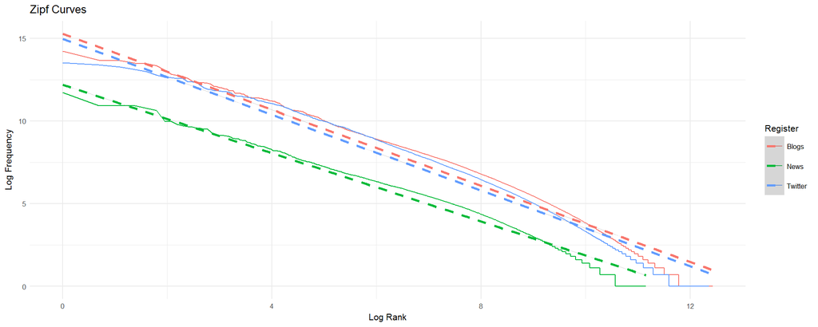

Figure 9: Zipf Plot for Blogs, News and Twitter Registers

Though the data appear to conform *reasonably* well, systematic variation in the residuals reveals a critique of Zipf’s law. The law computes the probability mass over the available data, and as such, doesn’t account for the probability of unseen words in a corpus. Mandelbrot [Mandelbrot61] proposed a generalization that more precisely fits the frequency distribution of language.

$$f(r) \propto \frac{1}{(r+\beta)^{\alpha}}$$
(3): Zipf-Aandelbrot Law

where $\alpha \approx 1$ and $\beta \approx 2.7$ [Mandelbrot61]. By “shifting” $r$ by $\beta$ probability mass is reserved for unseen words. The Zipf-Aandelbrot model can be trained using the languageR [Baayen2013] and the ZipfR [StefanEvert2015] packages; however, the process requires a computationally intensive vocabulary growth object which would add hours of processing time to the pipeline. Thus, the near-Zipfian word frequency distribution was considered “Zipfian enough” for the purposes of preparing a reasonable estimate of vocabulary and text size to achieve the target level of coverage.

### Lexical Size Estimate

The lexical size of the training set required to achieve the target coverage level in the test set was ascertained as follows. First, a frequency distribution of words in the test set that were also in the training set was calculated based upon frequencies in the test set. Sums of words were accumulated in order of rank, then divided by the test set vocabulary size $V$ to arrive at vocabulary coverage. The calculation was repeated for the training set word frequency distribution and both coverage curves are plotted below.

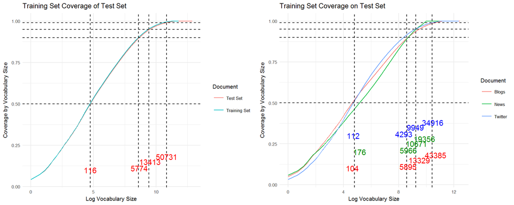

Figure 10: Coverage of Training and Test Set

The plot on the left shows the word frequency distribution of the training set (blue) vis-a-vis the training set coverage of the test set (red). The degree of fit merely indicates that the word frequency distribution of the training set models the word frequency distribution of the test set, considering only the words in the training set. The numbers indicate the training set vocabulary size required to achieve 50%, 90%, 95%, and 99% coverage of the vocabulary in the test set. Thus, a training set vocabulary size of 13,413 words would be required to achieve 95% coverage of the test set vocabulary. The plot on the right illustrates the training set vocabulary sizes required to reach various levels of coverage for each register in the test set.

Table 6: Coverage by Vocabulary Size $V$

| Document | 50% | 90% | 95% | 99% |
| --- | --- | --- | --- | --- |
| Blogs | 30.78 | 2,107.08 | 5,266.19 | 22,537.70 |
| News | 52.08 | 2,132.46 | 4,216.03 | 10,055.08 |
| Twitter | 33.14 | 1,534.47 | 3,930.78 | 18,138.21 |
| Training Corpus | 116.00 | 5,774.00 | 13,413.00 | 50,731.00 |
| Full Corpus | 555,723.00 | 555,723.00 | 555,723.00 | 555,723.00 |
| % Corpus | 0.02 | 1.04 | 2.41 | 9.13 |

Table 6 above and Table 7 below outline how the overall corpus vocabulary and token size estimates are allocated among the registers. In short, relative estimates for each register were calculated and multiplied by the overall estimates in Figure 10.

Table 7: Coverage by Lexical Size $N$

| Document | 50% | 90% | 95% | 99% |
| --- | --- | --- | --- | --- |
| Blogs | 1,853,839.30 | 3,336,912.19 | 3,522,295.59 | 3,670,602.70 |
| News | 128,569.12 | 231,424.06 | 244,281.60 | 254,566.92 |
| Twitter | 1,462,437.58 | 2,632,387.75 | 2,778,630.82 | 2,895,626.37 |
| Training Corpus | 3,444,846.00 | 6,200,724.00 | 6,545,208.00 | 6,820,796.00 |
| Full Corpus | 55,257,078.00 | 55,257,078.00 | 55,257,078.00 | 55,257,078.00 |
| % Corpus | 6.23 | 11.22 | 11.85 | 12.34 |

## Appendix C: Lexical Feature Analysis

Linguistic class information, particularly part-of-speech classifications, were to be incorporated into the language. Consequently, the training set must also represent the linguistic variation in the test corpus. Here, the lexical density, or more precisely, the distribution of lexical features in the test corpus was used to estimate the number and size of samples required, across and within registers, to achieve the lexical variation found in the test corpus.

### Total Corpus Sample Size

The first task was to determine which part-of-speech tags to include in the analysis. The objective was to cover 95% of the grammatically representative part-of-speech tags in the master corpus. The term grammatically is used to exclude punctuation and symbol tags and the word representative is used to designate those tags that have a frequency above a cut-off, which was in this case, 99%, thereby excluding exceedingly rare tags. Thus, the distributions of 15 part-of-speech tags, or lexical features, were analyzed across 75, 2,000-word samples from the combined corpus and from each register. Both content and grammatical (functional) lexical features were selected to capture potential inherent differences in statistical distribution. Table 8 exhibits the descriptive statistics, including the mean, standard deviation, and the coefficient of variation. Also known as the relative standard deviation, the coefficient of variation $c_v$ is a standard measure of dispersion of a frequency distribution and is defined as the ratio of the standard deviation $\sigma$ to the mean $\mu$. This ratio presents the degree of variation relative to the magnitude of the mean $\mu$.

Table 8: Descriptive statistics and estimates of required sample sizes

| Tag | Desc | Min | Max | Mean | Range | Standard Deviation | Coefficient of Variation | Tolerable Error | Required N |
| --- | --- | --- | --- | --- | --- | --- | --- | --- | --- |
| CC | Coordinating Conjunction | 34 | 101 | 64.32 | 67 | 18.85 | 0.29 | 3.22 | 131.92 |
| DT | Determiner | 135 | 243 | 183.47 | 108 | 27.25 | 0.15 | 9.17 | 33.90 |
| IN | Preposition/Subord. Conj. | 195 | 289 | 242.44 | 94 | 22.49 | 0.09 | 12.12 | 13.22 |
| JJ | Adjective | 123 | 178 | 153.25 | 55 | 12.03 | 0.08 | 7.66 | 9.47 |
| MD | Modal | 18 | 44 | 31.04 | 26 | 6.07 | 0.20 | 1.55 | 58.81 |
| NN | Noun, Singular Or Mass | 328 | 482 | 404.87 | 154 | 34.33 | 0.08 | 20.24 | 11.05 |
| NNS | Noun Plural | 85 | 157 | 111.75 | 72 | 15.17 | 0.14 | 5.59 | 28.30 |
| PRP | Personal Pronoun | 64 | 163 | 129.68 | 99 | 23.47 | 0.18 | 6.48 | 50.34 |
| RB | Adverb | 94 | 177 | 135.09 | 83 | 18.22 | 0.13 | 6.75 | 27.95 |
| VB | Verb Be, Base Form | 66 | 156 | 108.93 | 90 | 22.01 | 0.20 | 5.45 | 62.73 |
| VBD | Verb Be, Past | 39 | 96 | 62.72 | 57 | 14.73 | 0.23 | 3.14 | 84.71 |
| VBG | Verb Be, Gerund/Participle | 34 | 67 | 50.89 | 33 | 7.38 | 0.15 | 2.54 | 32.32 |
| VBN | Verb Be, Past Participle | 22 | 63 | 43.77 | 41 | 10.59 | 0.24 | 2.19 | 89.90 |
| VBP | Verb Be, Pres Non-3Rd P. | 36 | 105 | 71.19 | 69 | 17.95 | 0.25 | 3.56 | 97.69 |
| VBZ | Verb Be, Pres, 3Rd P. Sing | 41 | 85 | 63.56 | 44 | 9.36 | 0.15 | 3.18 | 33.29 |

Biber (1993) relates total linquistic variation of lexical features to total sample size for a representative corpus using the following formula:

$$n = \frac{s^2}{(te/t)^2}$$
where $n$ is the computed number of equal sized samples, $s$ is the standard deviation of the feature in the sample, $t$ is the $t$-value for the desired probability level, and the tolerable error, $te$, is the product of the $t$-value and the feature standard error of the mean. The $t$-value was specified at 1.96 and a separate estimate of the tolerable error was computed for each lexical feature to be 5% of the mean occurence.

Taking a conservative approach, a total corpus sample size of 132 samples of 2,000-word texts, was selected to accommodate the most widely varying features.

### Register Sample Size

Having calculated total corpus sample size, the relative proportions of subordinate registers were estimated. Each register would be allotted a minimum of 13 texts (10% of total corpus size). This left 93 texts to be divided proportionally among the three registers based upon their relative overall deviations, according to the following equations:

$$p = \frac{1}{n}\sum_{i=1}^{n} CV_1i\cdot x + \frac{1}{n}\sum_{i=1}^{n} CV_2i\cdot x + \frac{1}{n}\sum_{i=1}^{n} CV_3i\cdot x$$

The relative variation within the registers is as follows:

| Tag | Desc | Mean | Standard Deviation | Coefficient of Variation |
| --- | --- | --- | --- | --- |
| CC | Coordinating Conjunction | 78.61 | 8.75 | 0.11 |
| DT | Determiner | 205.31 | 14.52 | 0.07 |
| IN | Preposition/Subord. Conj. | 257.83 | 14.30 | 0.06 |
| JJ | Adjective | 148.77 | 13.79 | 0.09 |
| MD | Modal | 28.05 | 5.73 | 0.20 |
| NN | Noun, Singular Or Mass | 386.85 | 24.94 | 0.06 |
| NNS | Noun Plural | 114.96 | 16.08 | 0.14 |
| PRP | Personal Pronoun | 113.96 | 15.25 | 0.13 |
| RB | Adverb | 129.96 | 15.44 | 0.12 |
| VB | Verb Be, Base Form | 96.69 | 9.65 | 0.10 |
| VBD | Verb Be, Past | 70.31 | 13.43 | 0.19 |
| VBG | Verb Be, Gerund/Participle | 46.35 | 6.17 | 0.13 |
| VBN | Verb Be, Past Participle | 50.63 | 7.11 | 0.14 |
| VBP | Verb Be, Pres Non-3Rd P. | 55.37 | 10.40 | 0.19 |
| VBZ | Verb Be, Pres, 3Rd P. Sing | 61.75 | 10.12 | 0.16 |

| Tag | Desc | Mean | Standard Deviation | Coefficient of Variation |
| --- | --- | --- | --- | --- |
| CC | Coordinating Conjunction | 67.67 | 6.59 | 0.10 |
| DT | Determiner | 209.81 | 9.68 | 0.05 |
| IN | Preposition/Subord. Conj. | 253.11 | 13.26 | 0.05 |
| JJ | Adjective | 154.75 | 13.88 | 0.09 |
| MD | Modal | 24.44 | 5.48 | 0.22 |
| NN | Noun, Singular Or Mass | 473.45 | 24.72 | 0.05 |
| NNS | Noun Plural | 149.09 | 14.58 | 0.10 |
| PRP | Personal Pronoun | 78.75 | 12.71 | 0.16 |
| RB | Adverb | 89.08 | 10.97 | 0.12 |
| VB | Verb Be, Base Form | 74.04 | 9.59 | 0.13 |
| VBD | Verb Be, Past | 89.15 | 11.80 | 0.13 |
| VBG | Verb Be, Gerund/Participle | 45.57 | 6.61 | 0.14 |
| VBN | Verb Be, Past Participle | 53.44 | 7.58 | 0.14 |
| VBP | Verb Be, Pres Non-3Rd P. | 39.36 | 8.11 | 0.21 |
| VBZ | Verb Be, Pres, 3Rd P. Sing | 59.57 | 9.42 | 0.16 |

| Tag | Desc | Mean | Standard Deviation | Coefficient of Variation |
| --- | --- | --- | --- | --- |
| CC | Coordinating Conjunction | 44.64 | 7.03 | 0.16 |
| DT | Determiner | 154.69 | 12.13 | 0.08 |
| IN | Preposition/Subord. Conj. | 222.67 | 11.71 | 0.05 |
| JJ | Adjective | 151.71 | 11.14 | 0.07 |
| MD | Modal | 34.97 | 5.91 | 0.17 |
| NN | Noun, Singular Or Mass | 428.64 | 19.62 | 0.05 |
| NNS | Noun Plural | 101.28 | 10.63 | 0.10 |
| PRP | Personal Pronoun | 142.91 | 11.79 | 0.08 |
| RB | Adverb | 149.11 | 13.43 | 0.09 |
| VB | Verb Be, Base Form | 130.88 | 10.71 | 0.08 |
| VBD | Verb Be, Past | 51.76 | 8.83 | 0.17 |
| VBG | Verb Be, Gerund/Participle | 55.37 | 6.76 | 0.12 |
| VBN | Verb Be, Past Participle | 34.55 | 6.77 | 0.20 |
| VBP | Verb Be, Pres Non-3Rd P. | 89.59 | 8.11 | 0.09 |
| VBZ | Verb Be, Pres, 3Rd P. Sing | 68.07 | 9.28 | 0.14 |

To calculate relative sample size of the registers, the following equation was solved for $x$ based upon the relative overall deviations.

$$93 = 0.24 \cdot x + 0.25 \cdot x + 0.2 \cdot x$$

Thus: $x$ = 134.194

The proportional allocation for each register was computed as follows:

- Blogs: 0.24 X 134 = 33
- News: 0.25 X 134 = 33
- Twitter: 0.2 X 134 = 27

Finally, the minimum and proportional allocations were summed for each register, yielding the following sample sizes. Table 12 summarizes the density based sample size estimate vis-a-vis the master corpus size.

Table 12: Lexical feature sample size estimate

| Register | Words in Corpus | Base (# Texts) | Proportion (# Texts) | Sample Size (# Texts) | Sample Size (# Tokens) |
| --- | --- | --- | --- | --- | --- |
| Blogs | 37,110,484 | 13 | 33 | 46 | 92,000 |
| News | 2,608,731 | 13 | 33 | 46 | 92,000 |
| Twitter | 29,354,830 | 13 | 27 | 40 | 80,000 |
| Corpus | 69,074,045 | 39 | 93 | 132 | 264,000 |

Table 12 shows that range and distribution of lexical features in the master corpus would be obtained with 0.38% of the master corpus.

### Verify Lexical Feature Coverage

To ascertain lexical feature representation among the corpora, hypothesis testing was conduct whereby the null hypothesis, $H_0$, stated that no statistically significant differences were observed in the distributions of selected lexical features between the test and training corpora. The expected values under the null hypothesis were obtained from 75, 2,000-word samples from the master corpus and the observed values were extracted from 75, 2,000-word samples from the model training corpus and are as follows:

Table 13: Expected (null hypothesis) and observed lexical feature counts

| Tag | POS | Null | Observed |
| --- | --- | --- | --- |
| CC | Coordinating Conjunction | 67.7458 | 64.7733 |
| DT | Determiner | 192.0508 | 183.0000 |
| FW | Foreign Word | 5.9455 | 7.4000 |
| IN | Preposition/Subord. Conj. | 247.6271 | 241.1200 |
| JJ | Adjective | 154.0339 | 153.4533 |
| JJR | Adjective, Comparative | 6.9661 | 6.0000 |
| JJS | Adjective, Superlative | 4.4746 | 4.3521 |
| MD | Modal | 29.0678 | 30.9067 |
| NN | Noun, Singular Or Mass | 435.2542 | 406.2000 |
| NNS | Noun Plural | 126.1864 | 109.3600 |
| PRP | Personal Pronoun | 104.8983 | 127.7200 |
| RB | Adverb | 118.8305 | 138.2933 |
| RBR | Adverb, Comparative | 3.2807 | 3.2029 |
| RBS | Adverb, Superlative | 2.3571 | 1.9623 |
| RP | Particle | 10.1186 | 11.1067 |
| VB | Verb Be, Base Form | 96.5085 | 109.2133 |
| VBD | Verb Be, Past | 68.9492 | 64.7067 |
| VBG | Verb Be, Gerund/Participle | 49.9153 | 49.6800 |
| VBN | Verb Be, Past Participle | 45.5254 | 42.4933 |
| VBP | Verb Be, Pres Non-3Rd P. | 58.8136 | 72.0800 |
| VBZ | Verb Be, Pres, 3Rd P. Sing | 63.3898 | 62.9200 |
| WDT | Wh-Determiner | 8.2034 | 7.9200 |
| WP | Wh-Pronoun | 11.2373 | 11.9867 |
| WRB | Wh-Abverb | 12.1695 | 14.5467 |
| WP$ | Possessive Wh-Pronoun | 1.2500 | 1.0833 |

**Results** The results of the chi-squared test were:

- **Method:** Pearson’s Chi-squared test
- **Chi-Square Statistic:** 9.284966
- **Degrees of Freedom:** 24
- **p-value:** 0.9969224

The high p-value suggested that the result was not significant at α = 0.5. Thus the null hypothesis was not rejected.